# Clustering Methods

Mary Solomon

2/4/2021

Read data

```r
data <- fread("kpopdata.csv")
colnames(data)
```

```
##  [1] "Artist_uri"       "Artist"           "ArtistType"       "ArtistGender"
##  [5] "ArtistGen"        "ArtistDebut"      "song_name"        "song_uri"
##  [9] "album"            "album_uri"        "release_date"     "popularity"
## [13] "duration"         "acousticness"     "danceability"     "energy"
## [17] "instrumentalness" "key"              "liveness"         "loudness"
## [21] "mode"             "speechiness"      "tempo"            "time_signature"
## [25] "valence"          "duration_mmss"
```

# Clustering (unsupervised)

```r
mode1 <- data %>%
  dplyr::filter(mode == 1) %>%
  dplyr::select(popularity, duration, acousticness, danceability, energy,
         instrumentalness, loudness, speechiness, tempo, valence)
mode0 <- data %>%
  dplyr::filter(mode == 0) %>%
  dplyr::select(popularity, duration, acousticness, danceability, energy,
         instrumentalness, loudness, speechiness, tempo, valence)
```

The previous section aims to determine what kind of model we can build in order to predict which generation a kpop song is from based on audio/song features alone. However, could there be an alternative way to group the songs in the kpop genre based on audio/song features? Kpop Generations are grouped by the time and evolution of the kpop genre. By excluding time period, cultural trends, catchy visuals, dances, and only focusing on the audio features of the songs, what will the groups be defined by and how will it differ from the characteristics of the kpop generations observed in previous chapters?

Before we can start clustering, we will perform dimension reduction which will reduce allow us to analyze the data on fewer dimensions yet retain as much accountability for the variation as possible.

## Dimension Reduction: PCA

PCA is a dimension reduction technique that defines uncorrelated linear combinations that maximize the variance. Or in otherwords, PCA reduces the dimensions by with linear combinations that maximizes the information explained by the data. The assumptions made to perform PCA dimension reduction are as follows:

- No assumption on the distribution: this is very good because the majority of the predictors have non-normal skewed distributions
- No indpendence to be assumed for elements in a random vector: aka colinearity can exist between variables (???)
- Assume independence between observations in the random sample: this is a fair assumption to make. Each song is composed independently from one another, for the most part.
- most appropriate for continuous data: this could be a potential issue since there are categorical variables such as key, mode, time signature. Because of this, we will be analyzing the dimension reduction separately for those with a minor mode versus those with major mode, treating the two divisions of the category as separate groups. Time signature will be removed from the analysis since 97% of the songs are detected as being in 4/4 time. Key signature will also be removed as the integer values 0-11 represent a classification into a musical key where the distance between each are not equal.

#### PCA for Major mode (mode = 1)

standardized PCA

```r
pca1 <- prcomp(mode1, scale=TRUE)
t(pca1$rotation)
```

```
##       popularity     duration acousticness danceability       energy
## PC1  -0.08748438  0.234583079   0.42690453  -0.33000092 -0.502550975
## PC2  -0.32106911 -0.124030782   0.02418043   0.52107711 -0.133344025
## PC3   0.53871618 -0.570386340   0.22075205   0.10514772 -0.210756001
## PC4  -0.43227659 -0.146135712  -0.13095321  -0.14798888  0.068725625
## PC5   0.38690474 -0.146918673  -0.12791861  -0.17972502  0.133478910
## PC6  -0.07105038 -0.461889807   0.28457459   0.10259046 -0.144258204
## PC7  -0.46342498 -0.572430619  -0.02539270  -0.36711344  0.139363879
## PC8  -0.08116050  0.137525602   0.69410083  -0.22411269  0.125397590
## PC9  -0.16814265  0.036020862   0.26386284   0.59471737 -0.002764402
## PC10 -0.08841839 -0.008719108  -0.31921372  -0.07146938 -0.778934559
##      instrumentalness    loudness speechiness       tempo     valence
## PC1        0.08907296 -0.42119522 -0.17832687 -0.06629645 -0.41482115
## PC2        0.25645296 -0.26889336 -0.19557801 -0.58292764  0.27480385
## PC3        0.09483856 -0.19868646  0.47795734 -0.05647303 -0.01164534
## PC4        0.65819956 -0.20392858  0.27440415  0.43956569  0.06840671
## PC5        0.59122017  0.28679082 -0.48174870 -0.20199971 -0.23992247
## PC6       -0.16112117  0.03092504 -0.57917967  0.49775759  0.24323572
## PC7       -0.25460232  0.15452837  0.06067177 -0.33523815 -0.31297616
## PC8        0.18090349  0.42015194  0.16854394 -0.16609004  0.40190295
## PC9        0.09467478  0.38031074  0.12417847  0.17478351 -0.58952643
## PC10       0.04542931  0.49089664  0.10568157 -0.01751129  0.15441269
```

$$\hat y_1 = -0.087z_{Popularity} + 0.235z_{Duration} + 0.427z_{Acousticness} - 0.330z_{Danceability} - 0.502z_{Energy} + 0.089z_{Instrumantalness} - 0.421z_{Loudness} - 0.178z_{speechiness} -0.066z_{tempo} - 0.415z_{valence}
\\
\hat y_2 = -0.321z_{Popularity} - 0.124z_{Duration} + 0.024z_{Acousticness} + 0.521z_{Danceability} - 0.131z_{Energy} + 0.256z_{Instrumantalness} - 0.269z_{Loudness} - 0.196z_{speechiness} - 0.583z_{tempo} + 0.275z_{valence}
\\
\hat y_3 = 0.539z_{Popularity} - 0.570z_{Duration} + 0.221z_{Acousticness} + 0.105z_{Danceability} - 0.211z_{Energy} + 0.095z_{Instrumantalness} - 0.199z_{Loudness} + 0.478z_{speechiness} - 0.056z_{tempo} - 0.012z_{valence}
\\
\hat y_4 = -0.432z_{Popularity} - 0.146z_{Duration} - 0.131z_{Acousticness} - 0.148z_{Danceability} + 0.069z_{Energy} + 0.658z_{Instrumantalness} - 0.204z_{Loudness} + 0.274z_{speechiness} + 0.440z_{tempo} + 0.068z_{valence}
\\
\hat y_5 = 0.387z_{Popularity} - 0.147z_{Duration} - 0.128z_{Acousticness} - 0.180z_{Danceability} + 0.133z_{Energy} + 0.591z_{Instrumantalness} + 0.287z_{Loudness} - 0.482z_{speechiness} - 0.202z_{tempo} - 0.240z_{valence}$$

biplot

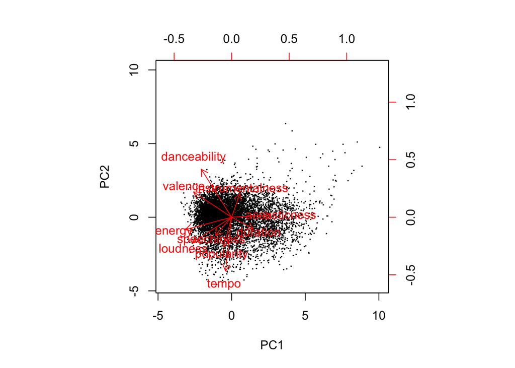

```r
biplot(pca1, scale = 0, xlabs=rep("·", nrow(mode1)))
```

examine amount of variance explained to choose optimal principal components

```r
pca1.var = pca1$sdev^2
pve1 = pca1.var/sum(pca1.var)
cve1 = cumsum(pve1)
pca1.var.explained <- data.frame("Variance" = pca1.var,
                                "Proportion_Variation" = pve1,
                                "Cummalitve_Proportion_Variation"= cve1,
                                "PC" = factor(c("PC1", "PC2", "PC3", "PC4", "PC5", "PC6", "PC7",
                                         "PC8", "PC9", "PC10"),
                                         levels = c("PC1", "PC2", "PC3", "PC4", "PC5", "PC6", "PC7",
                                         "PC8", "PC9", "PC10")))
pca1.var.explained
```

```
##     Variance Proportion_Variation Cummalitve_Proportion_Variation   PC
## 1  3.0379661           0.30379661                       0.3037966  PC1
## 2  1.3077608           0.13077608                       0.4345727  PC2
## 3  1.1871509           0.11871509                       0.5532878  PC3
## 4  1.0961557           0.10961557                       0.6629033  PC4
## 5  0.9233248           0.09233248                       0.7552358  PC5
## 6  0.7780514           0.07780514                       0.8330410  PC6
## 7  0.6314120           0.06314120                       0.8961822  PC7
## 8  0.5164992           0.05164992                       0.9478321  PC8
## 9  0.3592573           0.03592573                       0.9837578  PC9
## 10 0.1624219           0.01624219                       1.0000000 PC10
```

We can see that by the fifth principal component, 75.5% of the total variation in the data is explained. Therefore, it is reasonable to assume that these 5 principal components are sufficient for capturing the variation and explain the data of kpop songs. Furthermore, we can observe that the first principal component is the most influential by capturing 30% of information from the data. Whereas the remaining principal components explain lesser percentages of the data. This discrepancy in amount of variation explained is also displayed in the Scree plot.

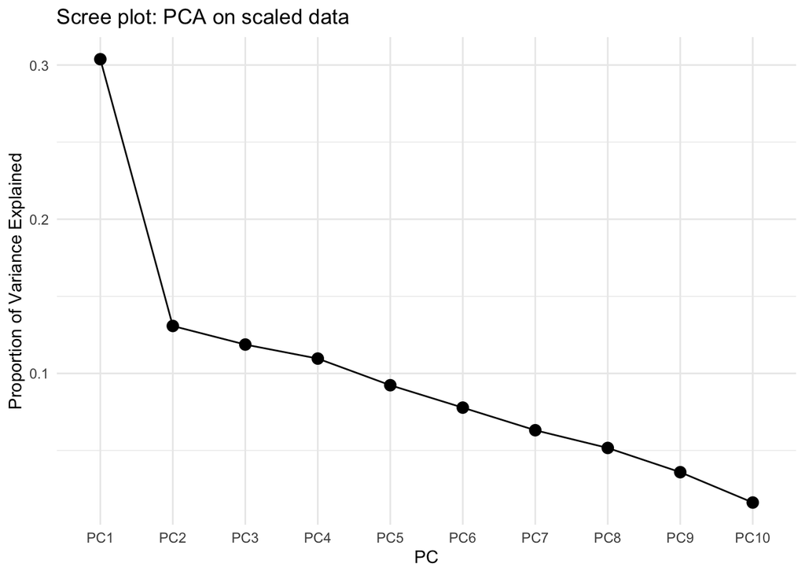

```r
pca1.var.explained %>%
  ggplot(aes(x=PC,y=Proportion_Variation, group=1))+
  ylab("Proportion of Variance Explained") +
  geom_point(size=3)+
  geom_line()+
  labs(title="Scree plot: PCA on scaled data") +
  theme_minimal()
```

#### PCA for minor mode (mode = 0)

standardized PCA

```r
pca0 <- prcomp(mode0, scale=TRUE)
t(pca0$rotation)
```

```
##       popularity    duration acousticness danceability      energy
## PC1   0.04334524 -0.13826657 -0.439981102   0.22176390  0.55636993
## PC2  -0.28319762 -0.10222926 -0.005363531   0.63350832 -0.14601180
## PC3   0.65363007 -0.47964362  0.233027648   0.16105589 -0.16370729
## PC4  -0.01718290 -0.54941852 -0.009372160   0.04563836 -0.05928624
## PC5   0.30748250 -0.17293836 -0.147091357  -0.09613684  0.09394803
## PC6   0.06442578  0.19453284 -0.368283226  -0.04456467  0.13220035
## PC7   0.57773779  0.53167459 -0.209529611   0.34175803 -0.19220798
## PC8  -0.08800537 -0.28786532 -0.631050620   0.12602942 -0.11828659
## PC9  -0.17187258  0.07144399  0.252041521   0.60505658  0.02233290
## PC10 -0.14363334 -0.01065667 -0.298458150  -0.10706256 -0.74905312
##      instrumentalness    loudness speechiness       tempo     valence
## PC1       -0.11532034  0.47553063  0.11610705  0.10686292  0.40294511
## PC2        0.12001960 -0.25323512 -0.26383183 -0.44849633  0.37064587
## PC3       -0.34202186  0.13126087  0.10875670 -0.29537581 -0.04884183
## PC4        0.54330441 -0.25744238  0.46915582  0.31722288  0.09982322
## PC5        0.57220179  0.19271184 -0.65755551 -0.04662998 -0.19166662
## PC6        0.25340421 -0.03216672  0.44467253 -0.64820525 -0.34606172
## PC7        0.12622132 -0.21706035  0.07840857  0.30277681  0.15820031
## PC8       -0.37271899 -0.32750754 -0.17548000  0.19776846 -0.40645094
## PC9        0.09470221  0.38849505  0.10465533  0.21482684 -0.56412605
## PC10       0.06848005  0.53175113  0.08348612 -0.01652251  0.15147267
```

INTERPRETATION OF THE PCs:

- PC1: The variables with positive direction coefficients are: Energy, Loudness, Valence, Danceability, Speechiness, Tempo, and Popularity. Energy, Loudness and Valence having the greatest weights, therefore accounting for the majority of the variation in the positive direction. The negative weighted variables are Acousticness, Duration and Instrumentalness where Acousticness has the highest weight. The variables with the positive direction weights are ones that an average person would assume to be associated with fun, upbeat, pop hits as opposed to the variables that are weighted in the negative direction. A fun observation to point out is the contrast to the songs with mode = 1. Notice how there are similar groupings of variables, but with the signs flipped. This shows that songs that are in a minor key (mode = 0) experience opposite direction for similar groupings as major and minor key songs tend to give off opposite moods/tones from one another musically.
- PC2: Variables weighted in the positive direction are: Danceability, Valence, Instrumentallness. Danceability being weighted the most heavily with a loading factor of 0.633. The variables weighted in the negative direction are: Tempo, Popularity, Loudness, Speechiness, Energy, Duraiton and Acousticness with Tempo holding the greatest negative weight at -0.448.
- PC3: For this PC, Popularity is weighted very heavily in the positive direction with a loading factor of 0.654 compared to other positively weighted variables such as Acousticness, Danceability, Loudness, and Speechiness. In the negative direction there is Duration, Instrumentalness, Tempo, Energy and Valence, where all variables except valence are weighted fairly equally in the negative direction, except Valence which is weighted much smaller than the rest.
- PC4: In the negative direction, Duration is weighted the most at -0.549, followed by Loudness, at -0.257 and Energy with a loading factor of just -0.059 and. In the positive direction, Instrumentalness carreis the most weight with a loading factor of 0.543, followed by speechiness with a weight of 0.469, thne Tempo, and Valence.
- PC5: The variables with weights in the positive direction are the variables Instrumentalness, Popularity, Loudness, and Energy where instrumentalness has the greatest weight due to its loading factor 0.572. The variables weighted in the negative direction are Speechiness, Valence, Duration, Acousticness, Danceability, and Tempo. Speechiness is the most heavily weighted with a loading factor of -0.658.

biplot

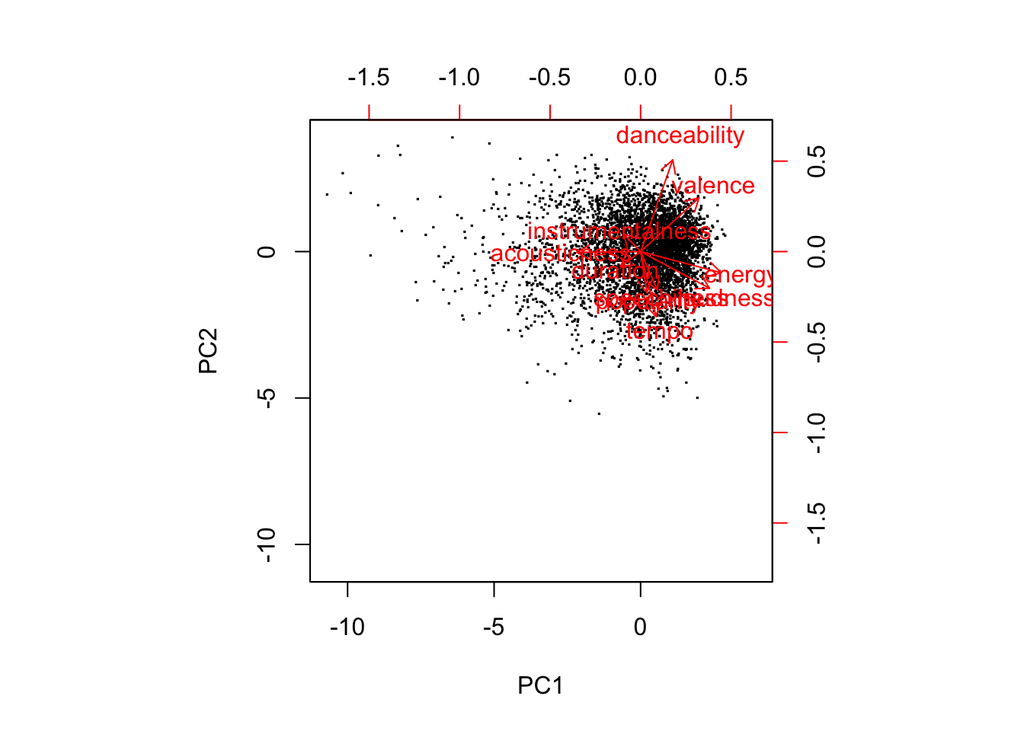

```r
biplot(pca0, scale = 0, xlabs=rep("·", nrow(mode0)))
```

examine amount of variance explained to choose optimal principal components

```r
pca0.var = pca0$sdev^2
pve0 = pca0.var/sum(pca0.var)
cve0 = cumsum(pve0)
pca0.var.explained <- data.frame("Variance" = pca0.var,
                                "Proportion_Variation" = pve0,
                                "Cummalitve_Proportion_Variation"= cve0,
                                "PC" = factor(c("PC1", "PC2", "PC3", "PC4", "PC5", "PC6", "PC7",
                                         "PC8", "PC9", "PC10"),
                                         levels = c("PC1", "PC2", "PC3", "PC4", "PC5", "PC6", "PC7",
                                         "PC8", "PC9", "PC10")))
pca0.var.explained
```

```
##     Variance Proportion_Variation Cummalitve_Proportion_Variation   PC
## 1  2.3860895           0.23860895                       0.2386090  PC1
## 2  1.4715942           0.14715942                       0.3857684  PC2
## 3  1.2323853           0.12323853                       0.5090069  PC3
## 4  1.1277912           0.11277912                       0.6217860  PC4
## 5  0.9479749           0.09479749                       0.7165835  PC5
## 6  0.8192458           0.08192458                       0.7985081  PC6
## 7  0.7050589           0.07050589                       0.8690140  PC7
## 8  0.6546053           0.06546053                       0.9344745  PC8
## 9  0.4147763           0.04147763                       0.9759521  PC9
## 10 0.2404785           0.02404785                       1.0000000 PC10
```

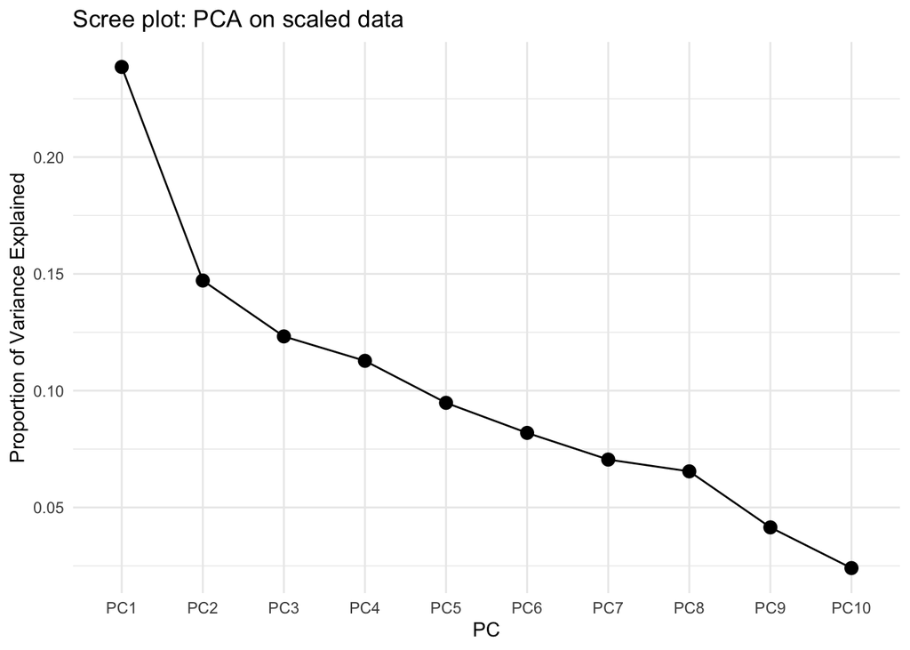

```r
pca0.var.explained %>%
  ggplot(aes(x=PC,y=Proportion_Variation, group=1))+
  ylab("Proportion of Variance Explained") +
  geom_point(size=3)+
  geom_line()+
  labs(title="Scree plot: PCA on scaled data") +
  theme_minimal()
```

## Clustering on PCA: Kmeans clustering

### for songs where mode = 0

Choosing number of groups (K) via elbow method

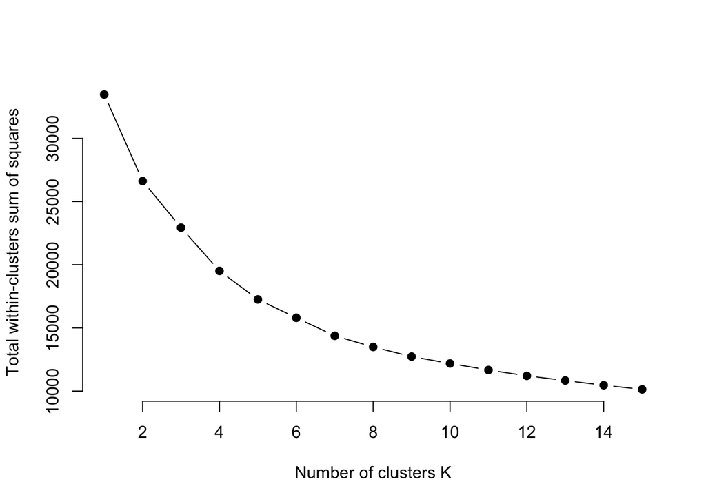

```r
pc0_1to5 <- data.frame(pca0$x[,1:5])
set.seed(123)
#compute total within cluster sum of square
wss <- function(k) {
  kmeans(pc0_1to5, k, iter.max = 1000, nstart = 25, algorithm = "Hartigan-Wong")$tot.withinss
}
k.vals <- 1:15
wss_values <- map_dbl(k.vals, wss)

plot(k.vals, wss_values,
       type="b", pch = 19, frame = FALSE,
       xlab="Number of clusters K",
       ylab="Total within-clusters sum of squares")
```

silhouette method

```r
library(factoextra)
```

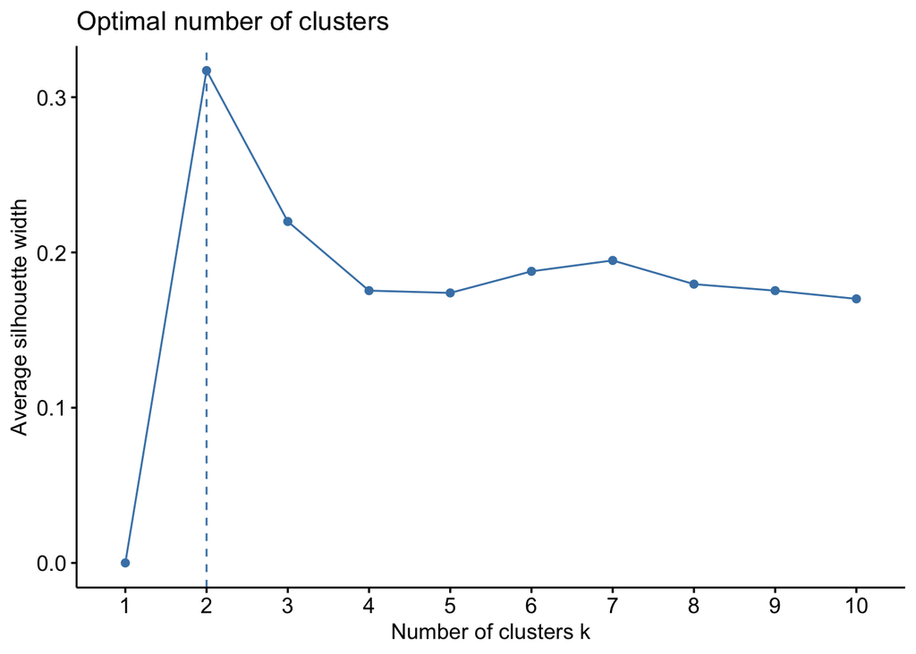

```r
fviz_nbclust(pc0_1to5, kmeans, method="silhouette")
```

visualize the two clusters

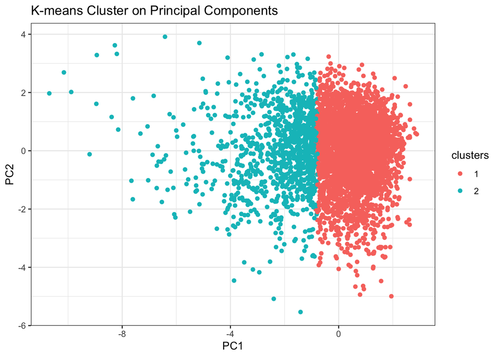

```r
set.seed(123)
k <- kmeans(pc0_1to5, 2, iter.max = 1000, nstart = 25, algorithm = "Hartigan-Wong")
pc0_1to5$clusters <- as.factor(k$cluster)
ggplot(pc0_1to5, aes(PC1, PC2, color = clusters)) + geom_point() +
  labs(title = "K-means Cluster on Principal Components", x = "PC1", y = "PC2") +
  theme_bw()
```

### for songs where mode = 1

Choosing number of groups (K) via elbow method

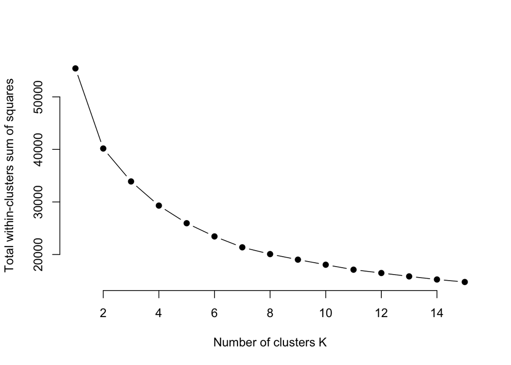

```r
pc1_1to5 <- data.frame(pca1$x[,1:5])
set.seed(123)
#compute total within cluster sum of square
wss <- function(k) {
  kmeans(pc1_1to5, k, iter.max = 1000, nstart = 25, algorithm = "Hartigan-Wong")$tot.withinss
}
k.vals <- 1:15
wss_values <- map_dbl(k.vals, wss)
plot(k.vals, wss_values,
       type="b", pch = 19, frame = FALSE,
       xlab="Number of clusters K",
       ylab="Total within-clusters sum of squares")
```

silhouette method

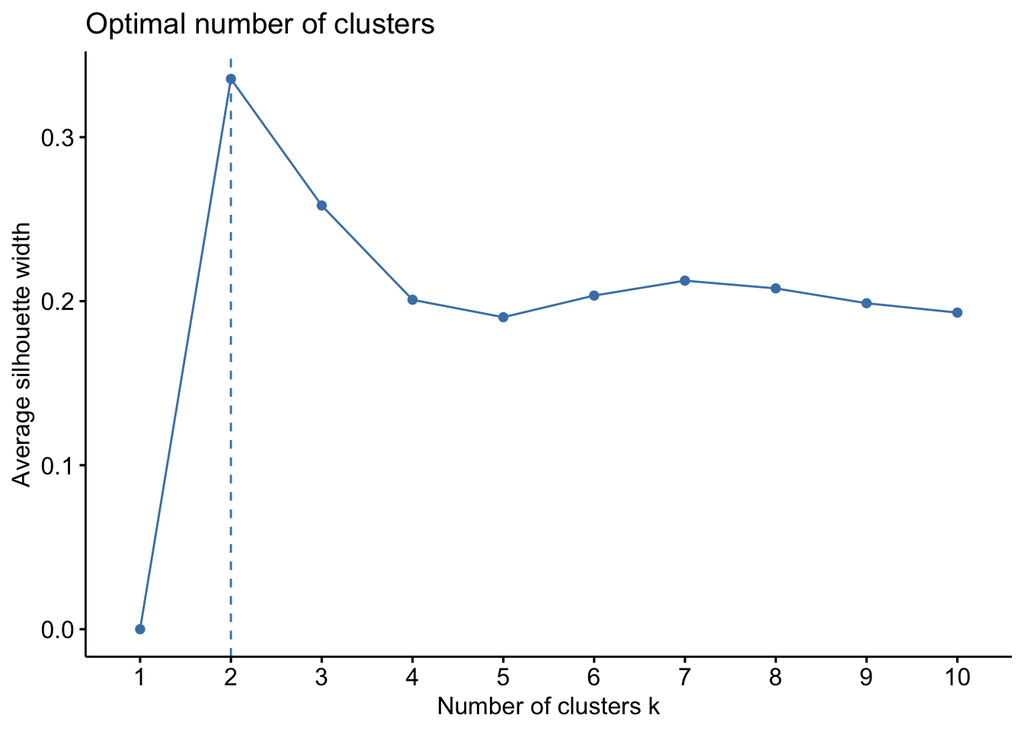

```r
fviz_nbclust(pc1_1to5, kmeans, method="silhouette")
```

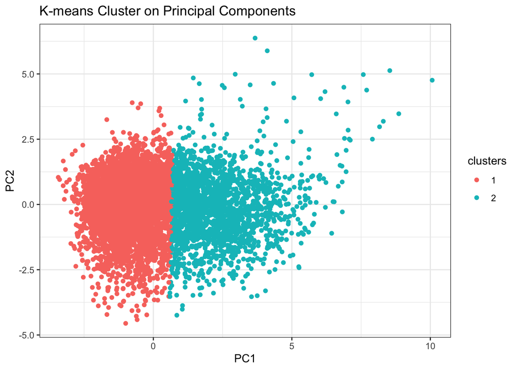

```r
set.seed(123)
k <- kmeans(pc1_1to5, 2, iter.max = 1000, nstart = 25, algorithm = "Hartigan-Wong")
pc1_1to5$clusters <- as.factor(k$cluster)
ggplot(pc1_1to5, aes(PC1, PC2, color = clusters)) + geom_point() +
  labs(title = "K-means Cluster on Principal Components", x = "PC1", y = "PC2") +
  theme_bw()
```

## Heirarchical Clustering: Ward's method

```r
mode0.st <- scale(mode0)
mode1.st <- scale(mode1)
```

column means and covariates of songs with mode == 0

```r
colMeans(mode0.st);cov(mode0.st)
```

```
##       popularity         duration     acousticness     danceability
##    -8.894606e-17    -1.505234e-17     7.933696e-17     2.959791e-16
##           energy instrumentalness         loudness      speechiness
##     3.727981e-16    -1.496213e-17    -1.850025e-16    -6.066149e-17
##            tempo          valence
##    -1.225987e-16    -4.776522e-17
```

```
##                    popularity     duration acousticness danceability
## popularity        1.000000000 -0.159124637  0.025653427  -0.05008908
## duration         -0.159124637  1.000000000  0.028051135  -0.16072246
## acousticness      0.025653427  0.028051135  1.000000000  -0.19680718
## danceability     -0.050089081 -0.160722460 -0.196807184   1.00000000
## energy           -0.025164278 -0.069599239 -0.548963093   0.07816429
## instrumentalness -0.104047202 -0.047727470  0.000217201  -0.02878326
## loudness          0.204303715 -0.083081772 -0.304174747   0.01644277
## speechiness       0.063981079 -0.109589353 -0.070157987  -0.06656659
## tempo             0.003275424 -0.002765617 -0.097533813  -0.23234447
## valence          -0.105363526 -0.126621689 -0.235211406   0.44341777
##                       energy instrumentalness    loudness speechiness
## popularity       -0.02516428     -0.104047202  0.20430372  0.06398108
## duration         -0.06959924     -0.047727470 -0.08308177 -0.10958935
## acousticness     -0.54896309      0.000217201 -0.30417475 -0.07015799
## danceability      0.07816429     -0.028783256  0.01644277 -0.06656659
## energy            1.00000000     -0.067503633  0.65270165  0.13600740
## instrumentalness -0.06750363      1.000000000 -0.20618408 -0.04600787
## loudness          0.65270165     -0.206184084  1.00000000  0.03275542
## speechiness       0.13600740     -0.046007871  0.03275542  1.00000000
## tempo             0.15088066      0.037254501  0.10083617  0.12793440
## valence           0.38144029     -0.045887807  0.24769595  0.04139298
##                         tempo     valence
## popularity        0.003275424 -0.10536353
## duration         -0.002765617 -0.12662169
## acousticness     -0.097533813 -0.23521141
## danceability     -0.232344471  0.44341777
## energy            0.150880658  0.38144029
## instrumentalness  0.037254501 -0.04588781
## loudness          0.100836170  0.24769595
## speechiness       0.127934398  0.04139298
## tempo             1.000000000  0.03413804
## valence           0.034138039  1.00000000
```

column means and covariates of songs with mode == 1

```r
colMeans(mode1.st);cov(mode1.st)
```

```
##       popularity         duration     acousticness     danceability
##    -1.007884e-17     3.096563e-16    -3.288080e-17    -3.102460e-16
##           energy instrumentalness         loudness      speechiness
##     1.249878e-16     1.258437e-18     1.095807e-16     1.120603e-16
##            tempo          valence
##     1.055468e-16    -2.308440e-16
```

```
##                   popularity    duration acousticness danceability      energy
## popularity        1.00000000 -0.17307300  -0.01483271   0.01832654  0.04317825
## duration         -0.17307300  1.00000000   0.14924367  -0.25511071 -0.21147704
## acousticness     -0.01483271  0.14924367   1.00000000  -0.33314406 -0.68594447
## danceability      0.01832654 -0.25511071  -0.33314406   1.00000000  0.30346697
## energy            0.04317825 -0.21147704  -0.68594447   0.30346697  1.00000000
## instrumentalness -0.10192463 -0.06403715   0.02405493  -0.06266768 -0.08043513
## loudness          0.20229978 -0.16114762  -0.44583422   0.19328608  0.73449168
## speechiness       0.13124244 -0.19796676  -0.15718950   0.08609541  0.21584603
## tempo             0.01305097 -0.02468909  -0.08493560  -0.20139080  0.13113402
## valence          -0.03602690 -0.26431483  -0.37476738   0.54809069  0.51613674
##                  instrumentalness   loudness speechiness       tempo
## popularity            -0.10192463  0.2022998  0.13124244  0.01305097
## duration              -0.06403715 -0.1611476 -0.19796676 -0.02468909
## acousticness           0.02405493 -0.4458342 -0.15718950 -0.08493560
## danceability          -0.06266768  0.1932861  0.08609541 -0.20139080
## energy                -0.08043513  0.7344917  0.21584603  0.13113402
## instrumentalness       1.00000000 -0.1900066 -0.04143303 -0.03113704
## loudness              -0.19000661  1.0000000  0.04926630  0.11709663
## speechiness           -0.04143303  0.0492663  1.00000000  0.13092671
## tempo                 -0.03113704  0.1170966  0.13092671  1.00000000
## valence               -0.06455267  0.3523813  0.16486967  0.04106101
##                      valence
## popularity       -0.03602690
## duration         -0.26431483
## acousticness     -0.37476738
## danceability      0.54809069
## energy            0.51613674
## instrumentalness -0.06455267
## loudness          0.35238126
## speechiness       0.16486967
## tempo             0.04106101
## valence           1.00000000
```

No issues of multicollinearity in either subset.

### Ward's Method: Mode 0

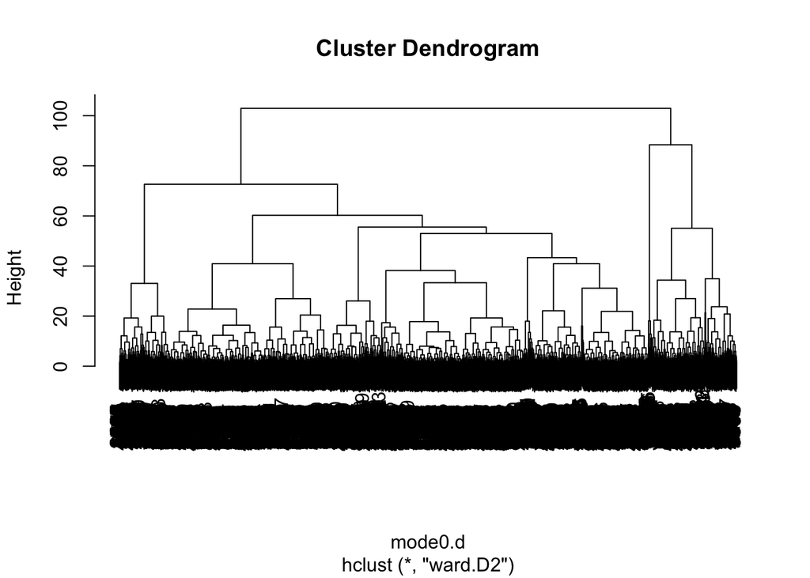

```r
mode0.d <- dist(mode0.st, method = "euclidean")
mode0_ward <- hclust(mode0.d, method = "ward.D2")
plot(mode0_ward)
```

The largest distance from the first cluster can be observed on the left side where the height has a distance of about 30. Therefore, Ward's method groups the dataset into 3 clusters.

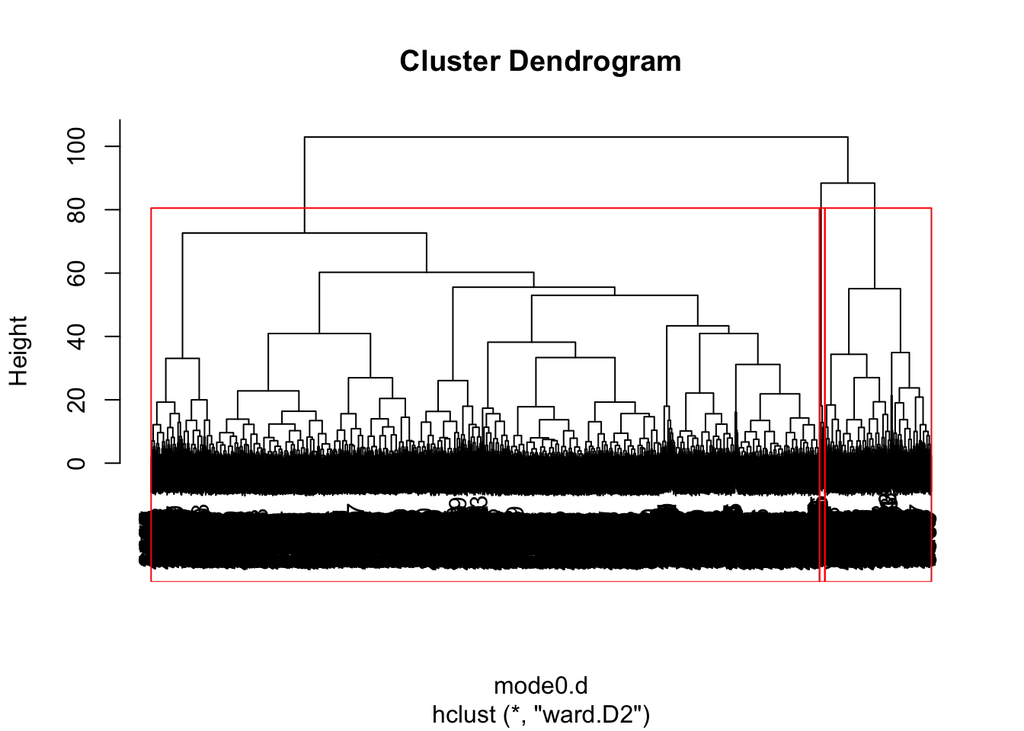

```r
plot(mode0_ward)
rect.hclust(mode0_ward, k=3, border="red")
```

```r
mode0.groups <- cutree(mode0_ward, k=3)
table(mode0.groups)
```

```
## mode0.groups
##    1    2    3
## 4003   32  638
```

```r
table(mode0.groups)/nrow(mode0)
```

```
## mode0.groups
##           1           2           3
## 0.856623154 0.006847849 0.136528996
```

### Ward's Method: Mode 1

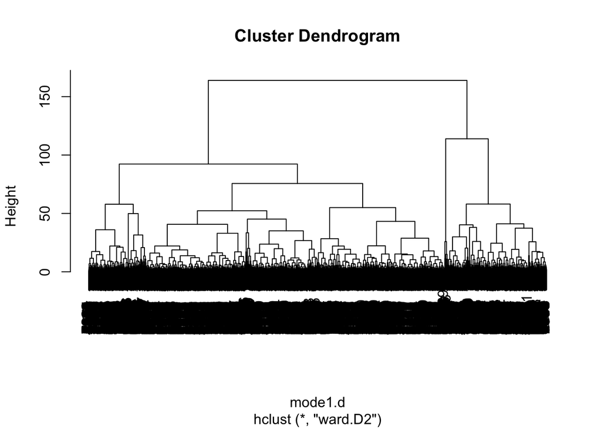

```r
mode1.d <- dist(mode1.st, method = "euclidean")
mode1_ward <- hclust(mode1.d, method = "ward.D2")
plot(mode1_ward)
```

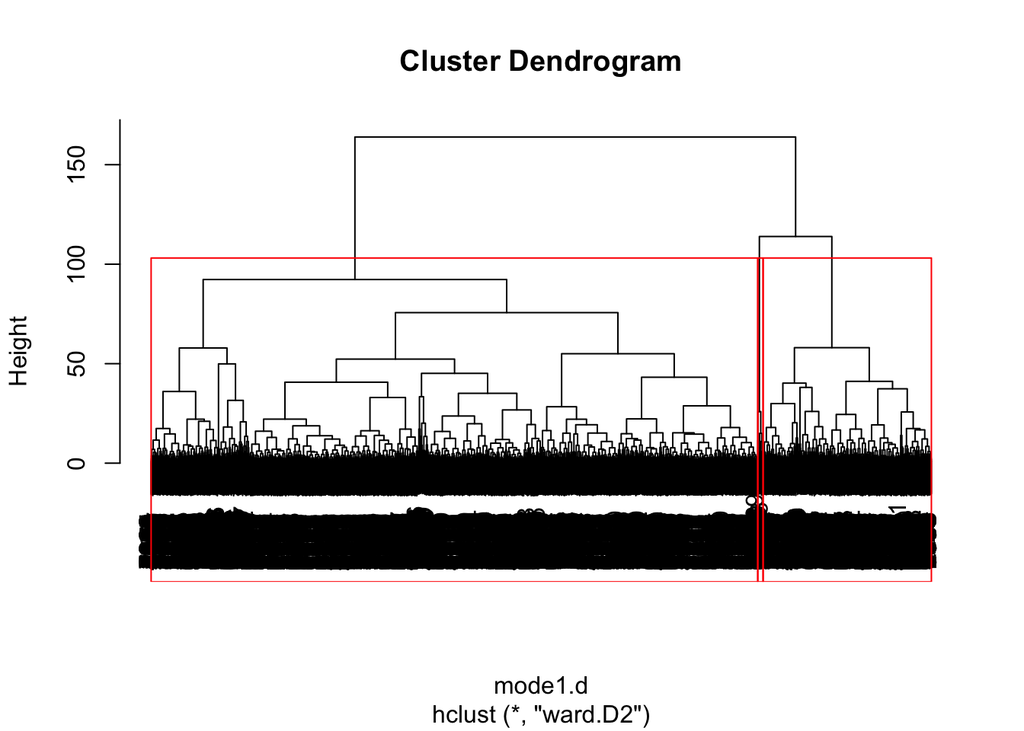

```r
plot(mode1_ward)
rect.hclust(mode1_ward, k=3, border="red")
```

```r
mode1.groups <- cutree(mode1_ward, k=3)
table(mode1.groups)
```

```
## mode1.groups
##    1    2    3
## 5706 1583   50
```

```r
table(mode1.groups)/nrow(mode1)
```

```
## mode1.groups
##           1           2           3
## 0.777490121 0.215696961 0.006812917
```